# Pemulusan Data Harga Rata-Rata Lelang Plat Nomor Mobil di Shanghai tahun 2002-2019

# Library / Packages

*Package* yang digunakan: `forecast`, `graphics`, `TTR`, `TSA`. Jika belum ada, install terlebih dahulu.

```r
#install.packages("forecast")
#install.packages("graphics")
#install.packages("TTR")
#install.packages("TSA")
```

Jika sudah ada, panggil library *package* tersebut.

```r
library("forecast")
```

```r
library("graphics")
library("TTR")
library("TSA")
```

# Data Preparation

```r
#setwd("C:/Users/LENOVO/Documents/MPDW/mpdw/P1")
#library(readxl)
#dt <- read_xlsx("Data_Shanghai.xlsx")
#write.table(dt, "Data_Shanghai.csv", sep=",", row.names = F)
#coba <- read.csv("Data_Shanghai.csv")
```

# Impor Data

```r
#install.packages("rio") #install jika belum ada
library(rio)
datashanghai <- import("https://raw.githubusercontent.com/aidara11/mpdw/main/Data/Data_Shanghai.csv")
```

# Eksplorasi Data

```r
View(datashanghai)    #melihat data
str(datashanghai)     #struktur data
```

```
## 'data.frame':    204 obs. of  2 variables:
##  $ Date         : IDate, format: "2002-01-01" "2002-02-01" ...
##  $ Average price: int  14735 14057 14662 16334 18357 20178 20904 21601 24040 27040 ...
```

```r
dim(datashanghai)     #dimensi data
```

```
## [1] 204   2
```

Mengubah data agar terbaca sebagai data deret waktu

```r
datashanghai.ts <- ts(datashanghai$`Average price`)
str(datashanghai.ts)
```

```
##  Time-Series [1:204] from 1 to 204: 14735 14057 14662 16334 18357 20178 20904 21601 24040 27040 ...
```

## Menampilkan ringkasan data

```r
summary(datashanghai.ts)
```

```
##    Min. 1st Qu.  Median    Mean 3rd Qu.    Max.
##   14057   34932   46037   54358   78142   93540
```

## Membuat plot

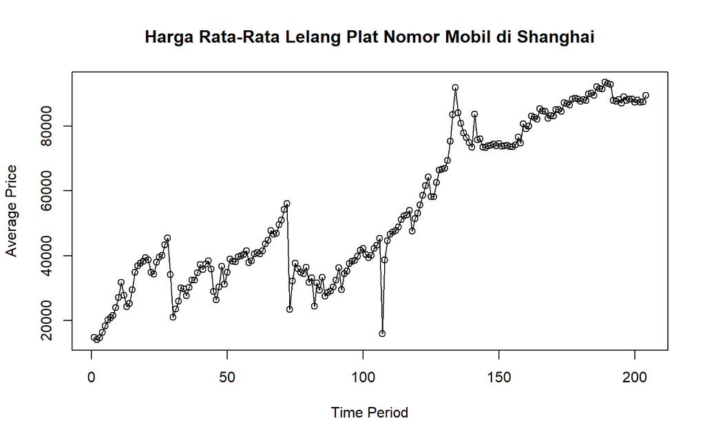

```r
ts.plot(datashanghai.ts, xlab="Time Period", ylab="Average Price",
        main = "Harga Rata-Rata Lelang Plat Nomor Mobil di Shanghai")
#membuat titik2 di plot data
points(datashanghai.ts)
```

Pada plot data deret waktu tersebut, dapat terlihat bahwa data berpola trend karena terjadi kenaikan sekuler jangka panjang (perubahan sistematis selama periode waktu yang panjang) dalam data. Oleh karena itu, metode pemulusan yang cocok adalah Double Moving Average (DMA) dan Double Exponential Smoothing (DES).

# Pemulusan (Smoothing)

## 1. Double Moving Average (DMA)

### Pembagian Data

```r
#membagi 80% data latih (training) dan 20% data uji (testing)
training_ma <- datashanghai[1:163,]
testing_ma <- datashanghai[164:204,]
train_ma.ts <- ts(training_ma$`Average price`)
test_ma.ts <- ts(testing_ma$`Average price`)
```

### Eksplorasi Data

Eksplorasi data dilakukan pada keseluruhan data, data latih serta data uji menggunakan plot data deret waktu.

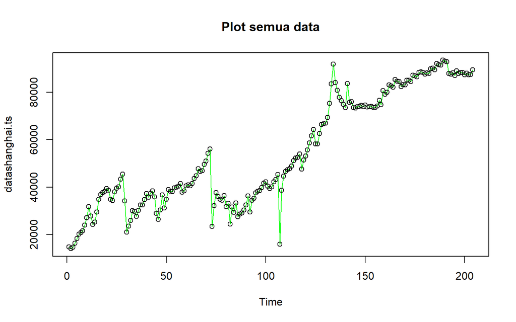

```r
#eksplorasi keseluruhan data
plot(datashanghai.ts, col="green",main="Plot semua data")
points(datashanghai.ts)
```

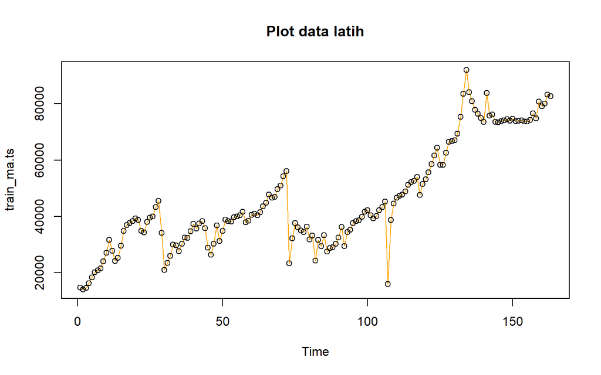

```r
#eksplorasi data latih
plot(train_ma.ts, col="orange",main="Plot data latih")
points(train_ma.ts)
```

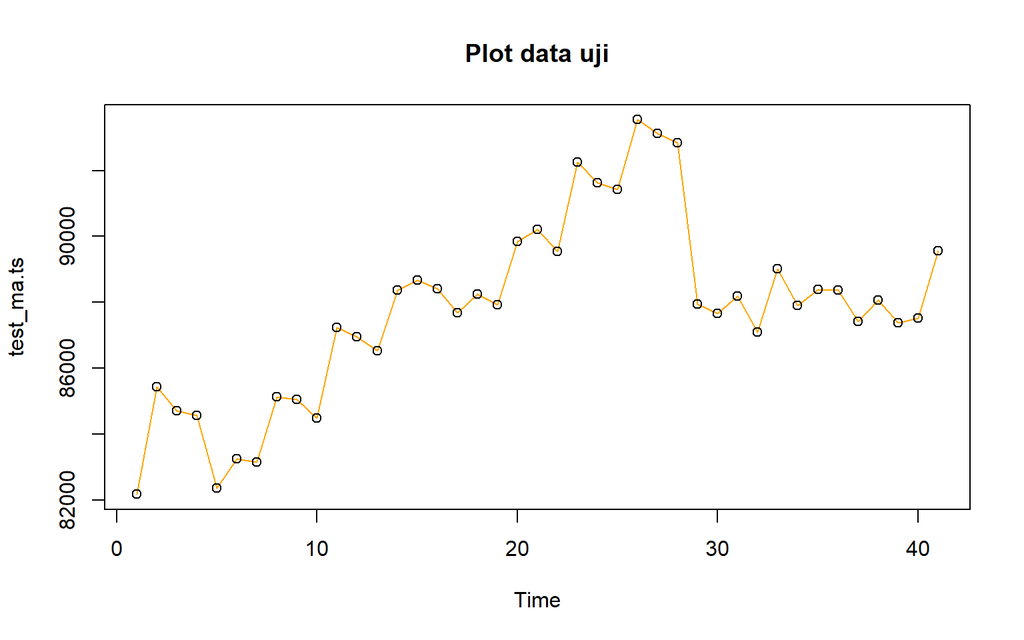

```r
#eksplorasi data uji
plot(test_ma.ts, col="orange",main="Plot data uji")
points(test_ma.ts)
```

Eksplorasi data juga dapat dilakukan menggunakan package `ggplot2` .

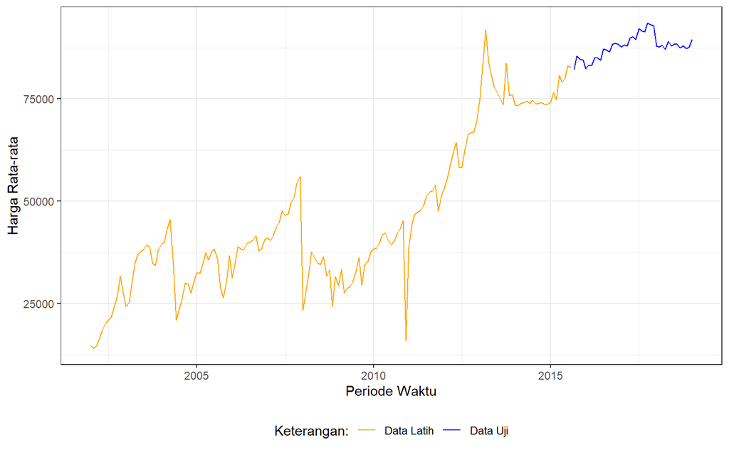

```r
#Eksplorasi dengan GGPLOT

library(ggplot2)
ggplot() +
  geom_line(data = training_ma, aes(x = Date, y = `Average price`, col = "Data Latih")) +
  geom_line(data = testing_ma, aes(x = Date, y = `Average price`, col = "Data Uji")) +
  labs(x = "Periode Waktu", y = "Harga Rata-rata", color = "Legend") +
  scale_colour_manual(name="Keterangan:", breaks = c("Data Latih", "Data Uji"),
                      values = c("orange", "blue")) +
  theme_bw() + theme(legend.position = "bottom",
                     plot.caption = element_text(hjust=0.5, size=12))
```

### Metode DMA

Metode pemulusan Double Moving Average (DMA) pada dasarnya mirip dengan Single Moving Average (SMA). Namun demikian, metode ini lebih cocok digunakan untuk pola data trend. Proses pemulusan dengan rata rata dalam metode ini dilakukan sebanyak 2 kali.

```r
data.sma <- SMA(train_ma.ts, n=4)

dma <- SMA(data.sma, n = 4)
At <- 2*data.sma - dma
Bt <- 2/(4-1)*(data.sma - dma)
data.dma<- At+Bt
data.ramal2<- c(NA, data.dma)

t = 1:41
f = c()

for (i in t) {
  f[i] = At[length(At)] + Bt[length(Bt)]*(i)
}

data.gab2 <- cbind(aktual = c(train_ma.ts,rep(NA,41)), pemulusan1 = c(data.sma,rep(NA,41)),pemulusan2 = c(data.dma, rep(NA,41)),At = c(At, rep(NA,41)), Bt = c(Bt,rep(NA,41)),ramalan = c(data.ramal2, f[-1]))
data.gab2
```

```
##        aktual pemulusan1 pemulusan2       At           Bt   ramalan
##   [1,]  14735         NA         NA       NA           NA        NA
##   [2,]  14057         NA         NA       NA           NA        NA
##   [3,]  14662         NA         NA       NA           NA        NA
##   [4,]  16334   14947.00         NA       NA           NA        NA
##   [5,]  18357   15852.50         NA       NA           NA        NA
##   [6,]  20178   17382.75         NA       NA           NA        NA
##   [7,]  20904   18943.25   22546.38 21105.12  1441.250000        NA
##   [8,]  21601   20260.00   23843.96 22410.38  1433.583333  22546.38
##   [9,]  24040   21680.75   25204.19 23794.81  1409.375000  23843.96
##  [10,]  27040   23396.25   27273.23 25722.44  1550.791667  25204.19
##  [11,]  31721   26100.50   31502.38 29341.62  2160.750000  27273.23
##  [12,]  27848   27662.25   32582.77 30614.56  1968.208333  31502.38
##  [13,]  24267   27719.00   30218.17 29218.50   999.666667  32582.77
##  [14,]  25254   27272.50   27412.40 27356.44    55.958333  30218.17
```

[output cut: 190 more lines]

### Visualisasi hasil pemulusan metode DMA

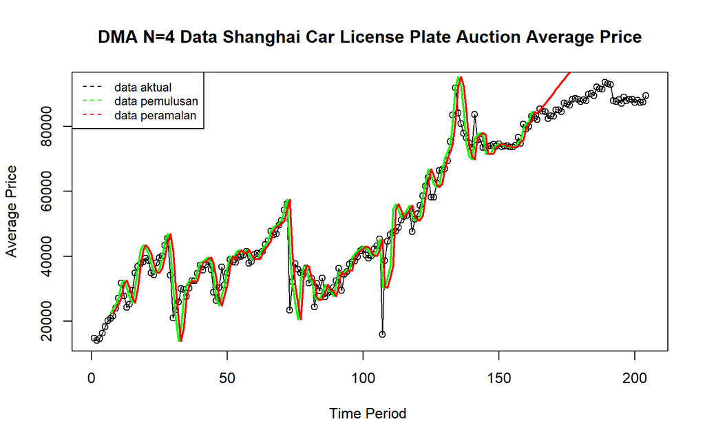

```r
ts.plot(datashanghai.ts, xlab="Time Period ", ylab="Average Price", main= "DMA N=4 Data Shanghai Car License Plate Auction Average Price")
points(datashanghai.ts)
lines(data.gab2[,3],col="green",lwd=2)
lines(data.gab2[,6],col="red",lwd=2)
legend("topleft",c("data aktual","data pemulusan","data peramalan"), lty=8, col=c("black","green","red"), cex=0.8)
```

Selanjutnya perhitungan akurasi dilakukan baik pada data latih maupun data uji. Perhitungan akurasi dilakukan dengan ukuran *Sum Squares Error* (SSE), *Mean Square Error* (MSE) dan *Mean Absolute Percentage Error* (MAPE).

### Akurasi Data Latih

```r
#Menghitung nilai keakuratan data latih

error_train.dma = train_ma.ts-data.ramal2[1:length(train_ma.ts)]
SSE_train.dma = sum(error_train.dma[8:length(train_ma.ts)]^2)
MSE_train.dma = mean(error_train.dma[8:length(train_ma.ts)]^2)
MAPE_train.dma = mean(abs((error_train.dma[8:length(train_ma.ts)]/train_ma.ts[8:length(train_ma.ts)])*100))

akurasi_train.dma <- matrix(c(SSE_train.dma, MSE_train.dma, MAPE_train.dma))
row.names(akurasi_train.dma)<- c("SSE", "MSE", "MAPE")
colnames(akurasi_train.dma) <- c("Akurasi m = 4")
akurasi_train.dma
```

```
##      Akurasi m = 4
## SSE   6.677238e+09
## MSE   4.280281e+07
## MAPE  1.159579e+01
```

Semakin kecil SSE, MSE, dan MAPE maka semakin akurat sebuah model dalam melakukan peramalan. Perhitungan akurasi pada data latih menggunakan nilai MAPE menghasilkan nilai MAPE diantara 10-20 sehingga nilai akurasi ini dapat dikategorikan baik. Selanjutnya, perhitungan nilai akurasi dilakukan pada data uji.

### Akurasi Data Uji

```r
#Menghitung nilai keakuratan data uji

error_test.dma = test_ma.ts-data.gab2[164:204,6]
SSE_test.dma = sum(error_test.dma^2)
MSE_test.dma = mean(error_test.dma^2)
MAPE_test.dma = mean(abs((error_test.dma/test_ma.ts*100)))

akurasi_test.dma <- matrix(c(SSE_test.dma, MSE_test.dma, MAPE_test.dma))
row.names(akurasi_test.dma)<- c("SSE", "MSE", "MAPE")
colnames(akurasi_test.dma) <- c("Akurasi m = 4")
akurasi_test.dma
```

```
##      Akurasi m = 4
## SSE   1.789688e+10
## MSE   4.365094e+08
## MAPE  1.989137e+01
```

Perhitungan akurasi pada data uji menghasilkan nilai MAPE di antara 10-20 sehingga nilai akurasi ini dapat dikategorikan sebagai baik.

## 2. Double Exponential Smoothing (DES)

Metode *Exponential Smoothing* adalah metode pemulusan dengan melakukan pembobotan menurun secara eksponensial. Nilai yang lebih baru diberi bobot yang lebih besar dari nilai terdahulu. Terdapat satu atau lebih parameter pemulusan yang ditentukan secara eksplisit dan hasil pemilihan parameter tersebut akan menentukan bobot yang akan diberikan pada nilai pengamatan.

Ada dua macam model, yaitu model tunggal dan ganda. Model tunggal atau Single Exponential Smoothing (SES) merupakan metode pemulusan yang tepat untuk data dengan pola stasioner atau konstan. Sedangkan model ganda atau Double Exponential Smoothing (DES) untuk data berpola tren. Data `harga rata-rata lelang plat nomor mobil di Shanghai` berpola tren sehingga menggunakan metode pemulusan DES.

### Pembagian Data

Pembagian data latih dan data uji dilakukan dengan perbandingan 80% data latih dan 20% data uji.

```r
#membagi 80% data latih (training) dan 20% data uji (testing)
training <- datashanghai[1:163,]
testing  <- datashanghai[164:204,]
train.ts <- ts(training$'Average price')
test.ts  <- ts(testing$'Average price')
```

### Eksplorasi Data

Eksplorasi dilakukan dengan membuat plot data deret waktu untuk keseluruhan data, data latih, dan data uji.

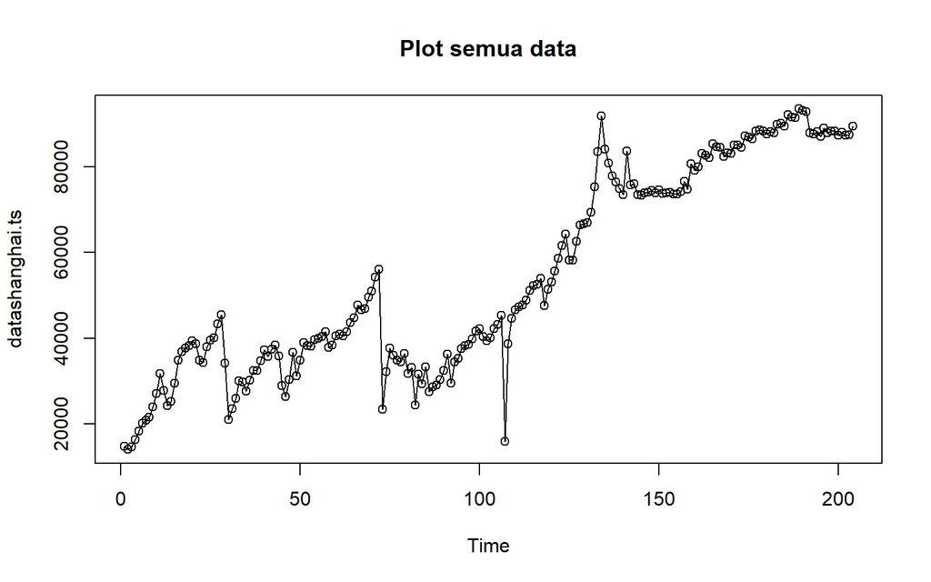

```r
#eksplorasi data
plot(datashanghai.ts, col="black",main="Plot semua data")
points(datashanghai.ts)
```

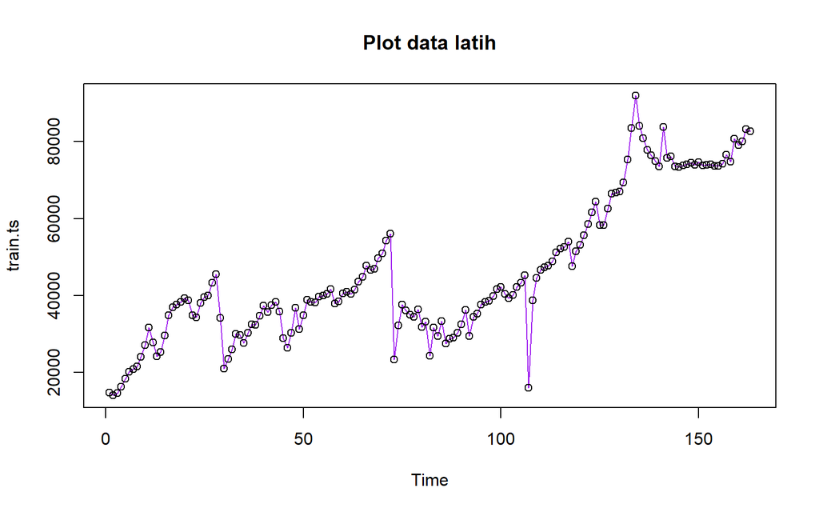

```r
plot(train.ts, col="purple",main="Plot data latih")
points(train.ts)
```

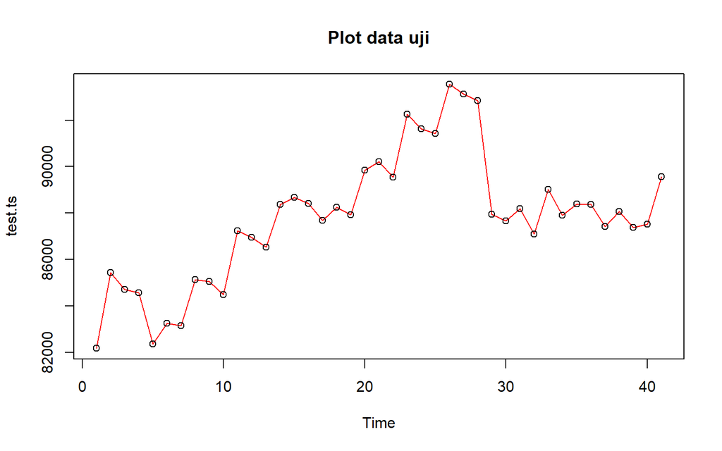

```r
plot(test.ts, col="red",main="Plot data uji")
points(test.ts)
```

Eksplorasi data juga dapat dilakukan menggunakan package `ggplot2` .

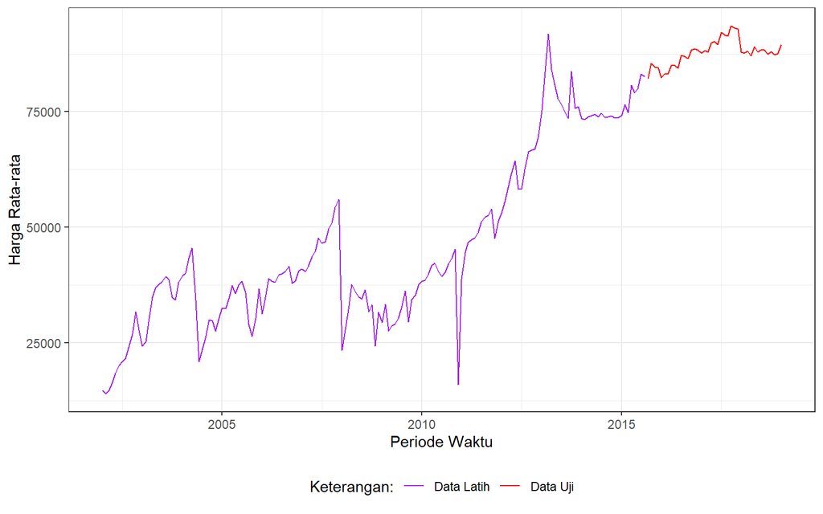

```r
#Eksplorasi dengan GGPLOT
library(ggplot2)
ggplot() +
  geom_line(data = training, aes(x = Date, y = `Average price`, col = "Data Latih")) +
  geom_line(data = testing, aes(x = Date, y = `Average price`, col = "Data Uji")) +
  labs(x = "Periode Waktu", y = "Harga Rata-rata", color = "Legend") +
  scale_colour_manual(name="Keterangan:", breaks = c("Data Latih", "Data Uji"),
                      values = c("purple", "red")) +
  theme_bw() + theme(legend.position = "bottom",
                     plot.caption = element_text(hjust=0.5, size=12))
```

### Metode DES

Metode pemulusan DES digunakan untuk data yang memiliki pola tren. Metode DES adalah metode semacam SES, hanya saja dilakukan dua kali, yaitu pertama untuk tahapan ‘level’ dan kedua untuk tahapan ‘tren’. Pemulusan menggunakan metode ini akan menghasilkan peramalan tidak konstan untuk periode berikutnya.

Pemulusan dengan metode DES ini akan menggunakan fungsi `HoltWinters()` . Nilai argumen `beta` diinisialisasi bersamaan dengan nilai `alpha` dan nilai argumen `gamma` dibuat `FALSE`.

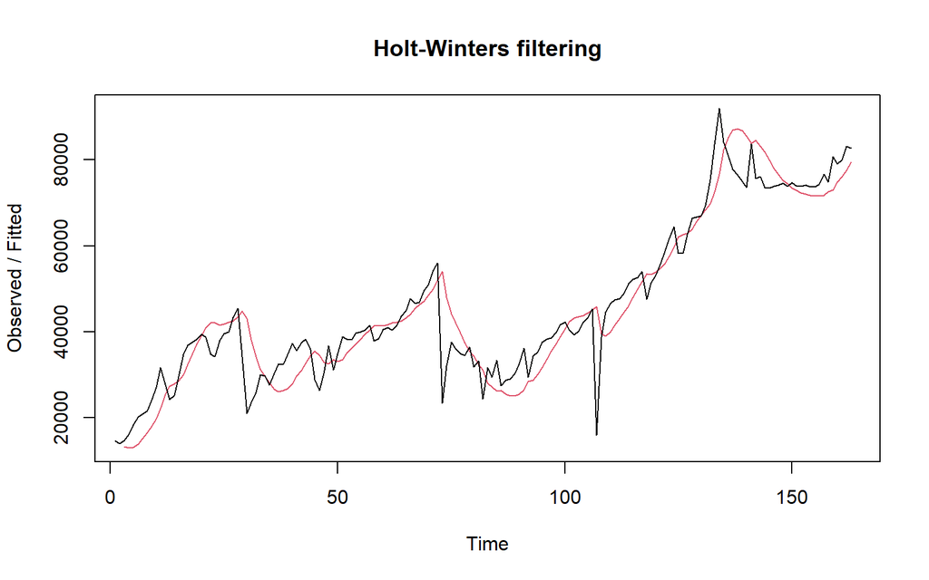

```r
#beta=0.2 dan alpha=0.2
des.1<- HoltWinters(train.ts, gamma = FALSE, beta = 0.2, alpha = 0.2)
plot(des.1)
```

```r
#ramalan
ramalandes1<- forecast(des.1, h=41)     #h = panjang periode
ramalandes1
```

```
##     Point Forecast    Lo 80     Hi 80    Lo 95     Hi 95
## 164       81008.37 72884.16  89132.58 68583.46  93433.28
## 165       81950.30 73595.39  90305.22 69172.56  94728.04
## 166       82892.24 74233.18  91551.29 69649.35  96135.12
## 167       83834.17 74793.27  92875.07 70007.30  97661.04
## 168       84776.10 75273.90  94278.31 70243.73  99308.47
## 169       85718.04 75675.51  95760.56 70359.32 101076.76
## 170       86659.97 76000.21  97319.73 70357.27 102962.67
## 171       87601.90 76251.24  98952.57 70242.56 104961.24
## 172       88543.84 76432.49 100655.18 70021.13 107066.54
## 173       89485.77 76548.10 102423.44 69699.31 109272.22
## 174       90427.70 76602.21 104253.19 69283.44 111571.97
## 175       91369.63 76598.75 106140.52 68779.52 113959.75
## 176       92311.57 76541.38 108081.75 68193.15 116429.98
## 177       93253.50 76433.44 110073.57 67529.43 118977.57
```

[output cut: 27 more lines]

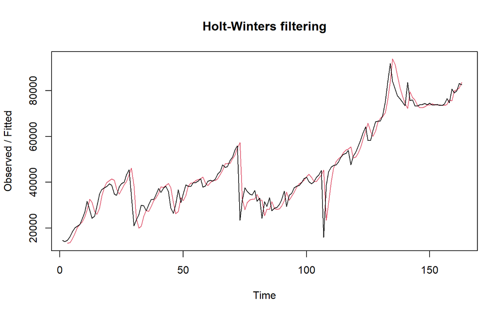

```r
#beta=0.3 dan aplha=0.6
des.2<- HoltWinters(train.ts, gamma = FALSE, beta = 0.3, alpha = 0.6)
plot(des.2)
```

```r
#ramalan
ramalandes2<- forecast(des.2, h=41)
ramalandes2
```

```
##     Point Forecast      Lo 80     Hi 80       Lo 95     Hi 95
## 164       84212.92  77069.817  91356.01   73288.489  95137.34
## 165       85356.20  76297.132  94415.27   71501.549  99210.86
## 166       86499.49  75137.696  97861.28   69123.126 103875.85
## 167       87642.78  73664.188 101621.37   66264.370 109021.18
## 168       88786.06  71924.720 105647.41   62998.864 114573.26
## 169       89929.35  69951.649 109907.05   59376.092 120482.61
## 170       91072.64  67767.740 114377.54   55430.871 126714.40
## 171       92215.93  65389.811 119042.04   51188.924 133242.93
## 172       93359.21  62830.844 123887.58   46670.102 140048.32
## 173       94502.50  60101.231 128903.77   41890.300 147114.70
## 174       95645.79  57209.545 134082.03   36862.628 154428.94
## 175       96789.07  54163.028 139415.12   31598.162 161979.99
## 176       97932.36  50967.916 144896.81   26106.440 169758.28
## 177       99075.65  47629.668 150521.63   20395.811 177755.48
```

[output cut: 27 more lines]

Nilai `y` adalah nilai data deret waktu, `gamma` adalah parameter pemulusan untuk komponen musiman, `beta` adalah parameter pemulusan untuk tren, dan `alpha` adalah parameter pemulusan untuk stasioner, serta `h` adalah banyaknya periode yang akan diramalkan.

### Visualisasi hasil pemulusan metode DES

Selanjutnya jika ingin membandingkan plot data latih dan data uji adalah sebagai berikut.

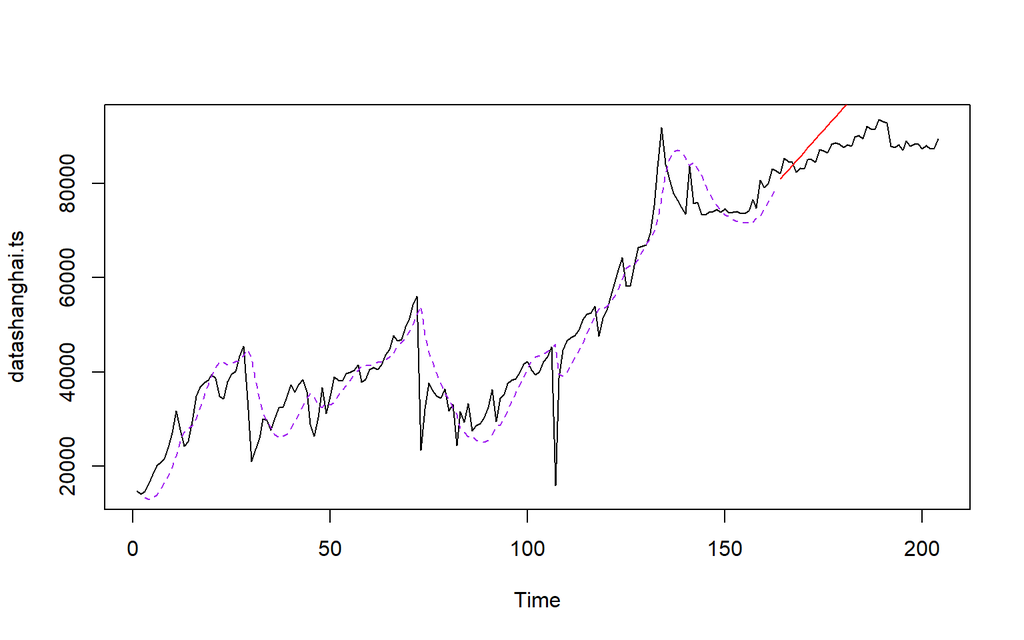

```r
#Visually evaluate the prediction
plot(datashanghai.ts)
lines(des.1$fitted[,1], lty=2, col="purple")
lines(ramalandes1$mean, col="red")
```

Untuk mendapatkan nilai parameter optimum dari DES, argumen `alpha` dan `beta` dapat dibuat `NULL` seperti berikut.

```r
#Lamda dan gamma optimum
des.opt<- HoltWinters(train.ts, gamma = FALSE)
des.opt
```

```
## Holt-Winters exponential smoothing with trend and without seasonal component.
##
## Call:
## HoltWinters(x = train.ts, gamma = FALSE)
##
## Smoothing parameters:
##  alpha: 0.722304
##  beta : 0.01760668
##  gamma: FALSE
##
## Coefficients:
##         [,1]
## a 82689.1861
## b   430.9262
```

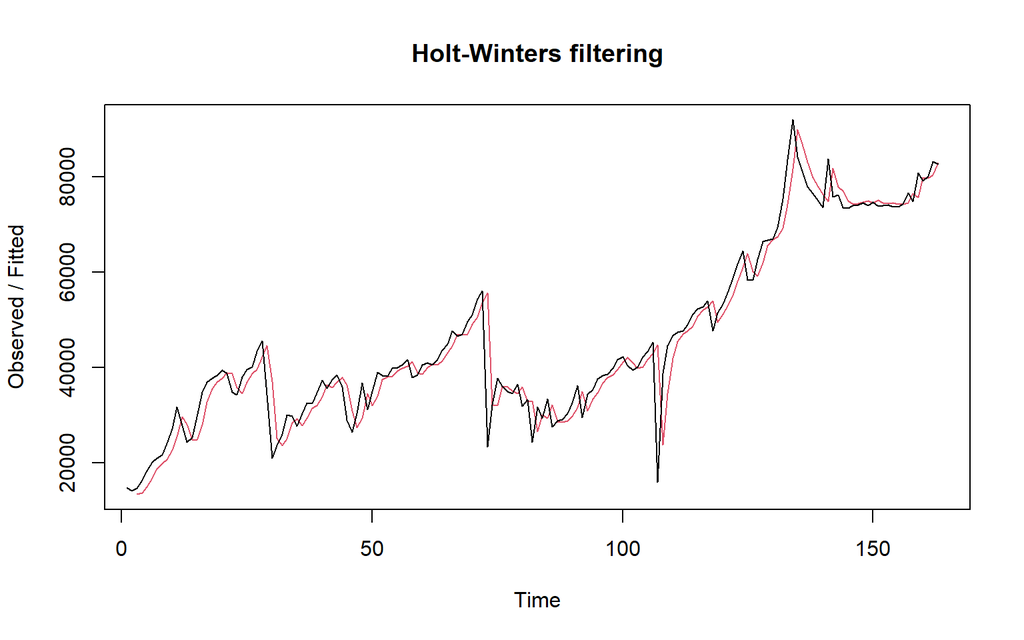

```r
plot(des.opt)
```

```r
#ramalan
ramalandesopt<- forecast(des.opt, h=41)   #h = panjang periode
ramalandesopt
```

```
##     Point Forecast    Lo 80     Hi 80    Lo 95     Hi 95
## 164       83120.11 76567.48  89672.74 73098.73  93141.50
## 165       83551.04 75418.76  91683.32 71113.79  95988.28
## 166       83981.96 74487.73  93476.20 69461.78  98502.15
## 167       84412.89 73690.45  95135.33 68014.33 100811.45
## 168       84843.82 72984.71  96702.92 66706.88 102980.75
## 169       85274.74 72345.81  98203.67 65501.65 105047.84
## 170       85705.67 71757.86  99653.48 64374.34 107037.00
## 171       86136.60 71209.95 101063.24 63308.27 108964.92
## 172       86567.52 70694.25 102440.79 62291.44 110843.60
## 173       86998.45 70204.88 103792.01 61314.90 112681.99
## 174       87429.37 69737.35 105121.40 60371.76 114486.99
## 175       87860.30 69288.11 106432.49 59456.59 116264.01
## 176       88291.23 68854.32 107728.13 58565.05 118017.41
## 177       88722.15 68433.66 109010.64 57693.59 119750.72
```

[output cut: 27 more lines]

Selanjutnya akan dilakukan perhitungan akurasi pada data latih maupun data uji dengan ukuran akurasi SSE, MSE dan MAPE.

### Akurasi Data Latih

```r
#Akurasi Data Training
ssedes.train1<-des.1$SSE
msedes.train1<-ssedes.train1/length(train.ts)
sisaandes1<-ramalandes1$residuals
head(sisaandes1)
```

```
## Time Series:
## Start = 1
## End = 6
## Frequency = 1
## [1]       NA       NA 1283.000 3325.080 5176.741 6249.000
```

```r
mapedes.train1 <- sum(abs(sisaandes1[3:length(train.ts)]/train.ts[3:length(train.ts)])
                      *100)/length(train.ts)

akurasides.1 <- matrix(c(ssedes.train1,msedes.train1,mapedes.train1))
row.names(akurasides.1)<- c("SSE", "MSE", "MAPE")
colnames(akurasides.1) <- c("Akurasi lamda=0.2 dan gamma=0.2")
akurasides.1
```

```
##      Akurasi lamda=0.2 dan gamma=0.2
## SSE                     6.440180e+09
## MSE                     3.951030e+07
## MAPE                    1.246787e+01
```

```r
ssedes.train2<-des.2$SSE
msedes.train2<-ssedes.train2/length(train.ts)
sisaandes2<-ramalandes2$residuals
head(sisaandes2)
```

```
## Time Series:
## Start = 1
## End = 6
## Frequency = 1
## [1]       NA       NA 1283.000 2632.260 3049.157 2465.068
```

```r
mapedes.train2 <- sum(abs(sisaandes2[3:length(train.ts)]/train.ts[3:length(train.ts)])
                      *100)/length(train.ts)

akurasides.2 <- matrix(c(ssedes.train2,msedes.train2,mapedes.train2))
row.names(akurasides.2)<- c("SSE", "MSE", "MAPE")
colnames(akurasides.2) <- c("Akurasi lamda=0.6 dan gamma=0.3")
akurasides.2
```

```
##      Akurasi lamda=0.6 dan gamma=0.3
## SSE                     4.971376e+09
## MSE                     3.049924e+07
## MAPE                    9.507739e+00
```

Hasil akurasi dari data latih skenario 2 dengan lamda=0.6 dan gamma=0.3 memiliki hasil yang lebih baik karena memiliki nilai SSE, MSE, dan MAPE yang lebih kecil. Berdasarkan nilai MAPE-nya, skenario 2 dapat dikategorikan peramalan sangat baik, sedangkan skenario 1 dikategorikan peramalan baik.

### Akurasi Data Uji

```r
#Akurasi Data Testing
selisihdes1 <- ramalandes1$mean - testing$`Average price`
selisihdes1
```

```
## Time Series:
## Start = 164
## End = 204
## Frequency = 1
##  [1] -1163.631 -3473.697 -1810.764  -737.831  2424.102  2474.036  3511.969
##  [8]  2474.902  3485.835  5002.768  3192.702  4423.635  5788.568  4894.501
## [15]  5530.435  6725.368  8394.301  8781.234 10047.168  9055.101  9638.034
## [22] 11256.967  9480.901 11043.834 12199.767 11016.700 12368.634 13592.567
## [29] 19446.500 20664.433 21090.367 23119.300 22132.233 24192.166 24654.100
## [36] 25611.033 27507.966 27789.899 29427.832 30235.766 29120.699
```

```r
SSEtestingdes1<-sum(selisihdes1^2)
MSEtestingdes1<-SSEtestingdes1/length(testing$`Average price`)
MAPEtestingdes1<-sum(abs(selisihdes1/testing$`Average price`)*100)/length(testing$`Average price`)

selisihdes2<-ramalandes2$mean-testing$`Average price`
selisihdes2
```

```
## Time Series:
## Start = 164
## End = 204
## Frequency = 1
##  [1]  2040.91543   -67.79747  1796.48964  3070.77674  6434.06385  6685.35096
##  [7]  7924.63806  7088.92517  8301.21227 10019.49938  8410.78648  9843.07359
## [13] 11409.36069 10716.64780 11553.93490 12950.22201 14820.50911 15408.79622
## [19] 16876.08332 16085.37043 16869.65753 18689.94464 17115.23175 18879.51885
## [25] 20236.80596 19255.09306 20808.38017 22233.66727 28288.95438 29708.24148
## [31] 30335.52859 32565.81569 31780.10280 34041.38990 34704.67701 35862.96411
## [37] 37961.25122 38444.53833 40283.82543 41293.11254 40379.39964
```

```r
SSEtestingdes2<-sum(selisihdes2^2)
MSEtestingdes2<-SSEtestingdes2/length(testing$`Average price`)
MAPEtestingdes2<-sum(abs(selisihdes2/testing$`Average price`)*100)/length(testing$`Average price`)

selisihdesopt<-ramalandesopt$mean-testing$`Average price`
selisihdesopt
```

```
## Time Series:
## Start = 164
## End = 204
## Frequency = 1
##  [1]   948.1123 -1872.9616  -721.0354  -159.1092  2491.8169  2030.7431
##  [7]  2557.6692  1009.5954  1509.5215  2515.4477   194.3738   914.3000
## [13]  1768.2262   363.1523   488.0785  1172.0046  2329.9308  2205.8569
## [19]  2960.7831  1457.7092  1529.6354  2637.5616   350.4877  1402.4139
## [25]  2047.3400   353.2662  1194.1923  1907.1185  7250.0446  7956.9708
## [31]  7871.8969  9389.8231  7891.7493  9440.6754  9391.6016  9837.5277
## [37] 11223.4539 10994.3800 12121.3062 12418.2323 10792.1585
```

```r
SSEtestingdesopt<-sum(selisihdesopt^2)
MSEtestingdesopt<-SSEtestingdesopt/length(testing$`Average price`)
MAPEtestingdesopt<-sum(abs(selisihdesopt/testing$`Average price`)*100)/length(testing$`Average price`)

akurasitestingdes <-
  matrix(c(SSEtestingdes1,MSEtestingdes1,MAPEtestingdes1,SSEtestingdes2,MSEtestingdes2,
           MAPEtestingdes2,SSEtestingdesopt,MSEtestingdesopt,MAPEtestingdesopt),
         nrow=3,ncol=3)
row.names(akurasitestingdes)<- c("SSE", "MSE", "MAPE")
colnames(akurasitestingdes) <- c("des ske1","des ske2","des opt")
akurasitestingdes
```

```
##          des ske1     des ske2      des opt
## SSE  9.898361e+09 2.129104e+10 1.345996e+09
## MSE  2.414234e+08 5.192937e+08 3.282918e+07
## MAPE 1.402999e+01 2.181454e+01 4.657467e+00
```

# Perbandingan Metode DMA dan DES

```r
perbandingan_metode <-
  matrix(c(SSE_test.dma, MSE_test.dma, MAPE_test.dma, SSEtestingdesopt,MSEtestingdesopt,MAPEtestingdesopt),
         nrow=3,ncol=2)
row.names(perbandingan_metode)<- c("SSE", "MSE", "MAPE")
colnames(perbandingan_metode) <- c("DMA","DES")
perbandingan_metode
```

```
##               DMA          DES
## SSE  1.789688e+10 1.345996e+09
## MSE  4.365094e+08 3.282918e+07
## MAPE 1.989137e+01 4.657467e+00
```

Metode DMA dan DES dapat dibandingkan hasilnya dengan menggunakan ukuran akurasi yang sama, yaitu SSE, MSE, dan MAPE dari data uji. Didapatkan hasil bahwa metode DES lebih baik dibandingkan metode DMA dilihat dari SSE, MSE, dan MAPE yang lebih kecil nilainya. Berdasarkan nilai MAPE-nya, metode DES memberikan peramalan dengan akurasi yang sangat baik, sedangkan metode DMA hanya memberikan peramalan dengan akurasi yang baik.